# WTCIII-Figures

Court Campany

June 23, 2015

#### Design

- WTCIII was a warming experiment with ambient and +3°C warming (n=6). A drought manipulation was added in the last few months of the experiment but is not included here.
- Sun leaves were measured in the upper canopy at their current PPFD. Shade leaves were measured in the lower/middle canopy, first at their current PPFD and then again at sun leaf PPFD as a simulated sunfleck (Shade-Low light & Shade-High light).
- New fully expanded leaves were measured. Shade leaves were sampled into the middle canopy as the experiment progressed to avoid issues with leaf age.
- Leaf physiological measurements were taken at their current temperature (ambient, +3°C). Thus, data below represent a large range of temperatures from 18-35°C.

#### Figures

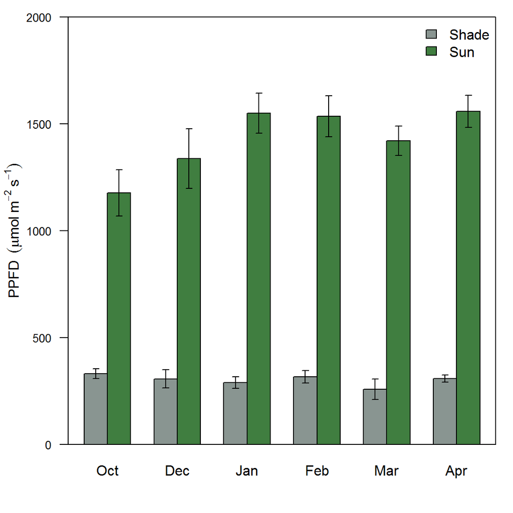

Figure 1. Local light environment for sun and shade leaves for each gas exchange campaign. Means with standard errors represent 1 m integrated PPFD (n=5), measured with a ceptometer, at the canopy height of each selected leaf.

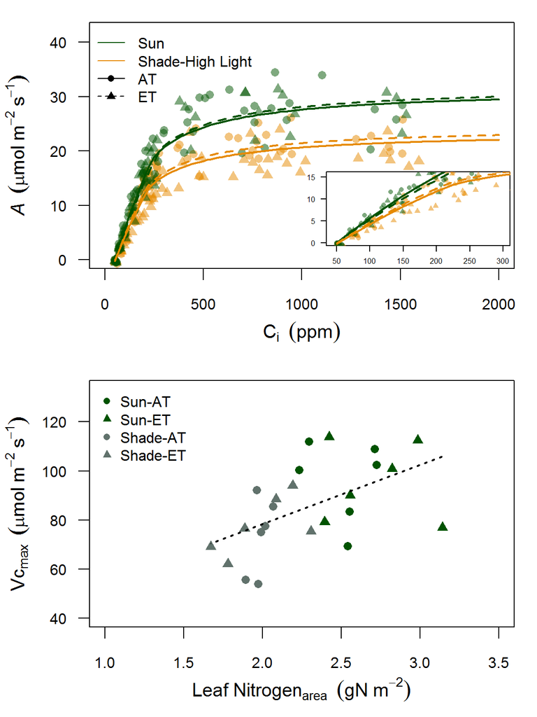

Figure2. (a) Photosynthetic CO<sub>2</sub> response (ACi) curves for sun and shade leaves at elevated (ET) and ambient (AT) temperature treatments. ACi curves were developed once for all trees, before the initiation of the drought treatment, at 25°C and at saturating light (1800 $\mu$mols m<sup>-1</sup> s<sup>-1</sup>). (b) The relationship between Vc<sub>max</sub> and mean leaf nitrogen<sub>area</sub> for each chamber, including sun leaves and shade leaves at low light. For (b) the dashed line represents the significant linear model fit for all leaves with a marginal and conditional r<sup>2</sup> of 0.28 and 0.35, respectively.

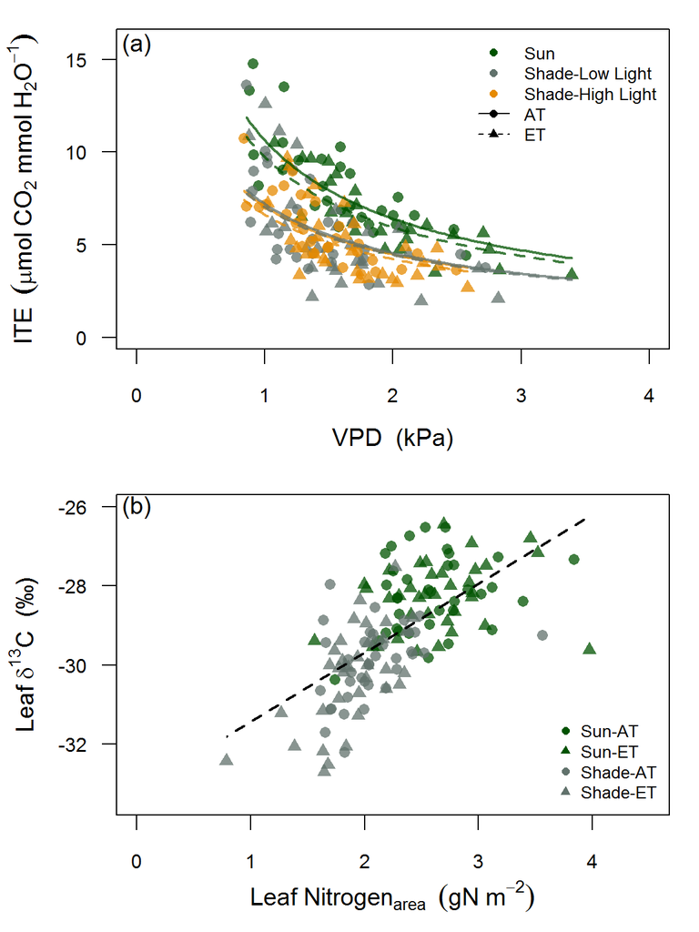

Figure 3. (a) Response of instantaneous water use efficiency (ITE) to leaf vapor pressure deficit (VPD) for sun leaves and shade leaves at both low and high light with elevated and ambient temperature treatments. (b) The relationship between leaf $\delta$<sup>13</sup>C and leaf nitrogen<sub>area</sub> for sun leaves and shade leaves at low light. For (a) VPD is the leaf to air pressure difference inside the gas exchange cuvette and lines represent predictions from the optimal ITE model with a g1 value for each leaf type and treatment. For (b) the dashed line represents the significant linear model fit for all leaves with a marginal and conditional r<sup>2</sup> of 0.41 and 0.45, respectively.

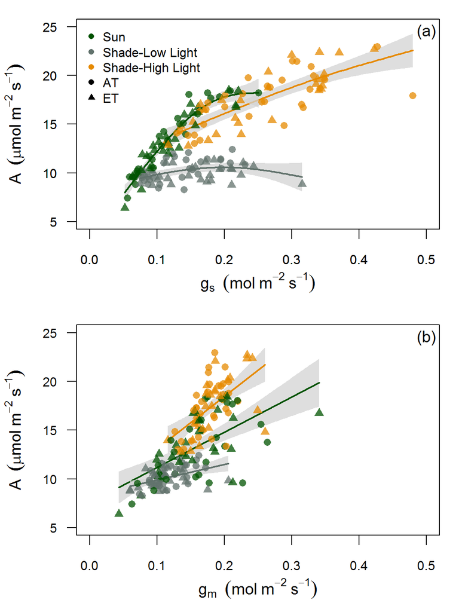

Figure 4. The response of leaf photosynthesis rates to stomatal conductance (a) and mesophyll conductance (b) for sun leaves and shade leaves at both low and high light with elevated and ambient temperature treatments. The response of shade leaf physiology to high light was recorded once both photosynthesis and stomatal conductance were stable in the gas exchange leaf cuvette (ca. 25min). Lines represent either smoothed regressions from a generalized additive model fit (a) or linear model fits (b). Grey areas are approximately 95% confidence intervals from the mean.

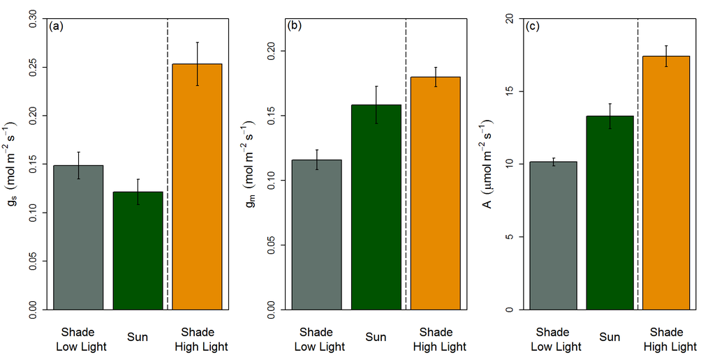

The mean stomatal conductance (a), mesophyll conductance (b) and photosynthesis rate (c) of sun leaves and shade leaves at both low and high light with standard errors.

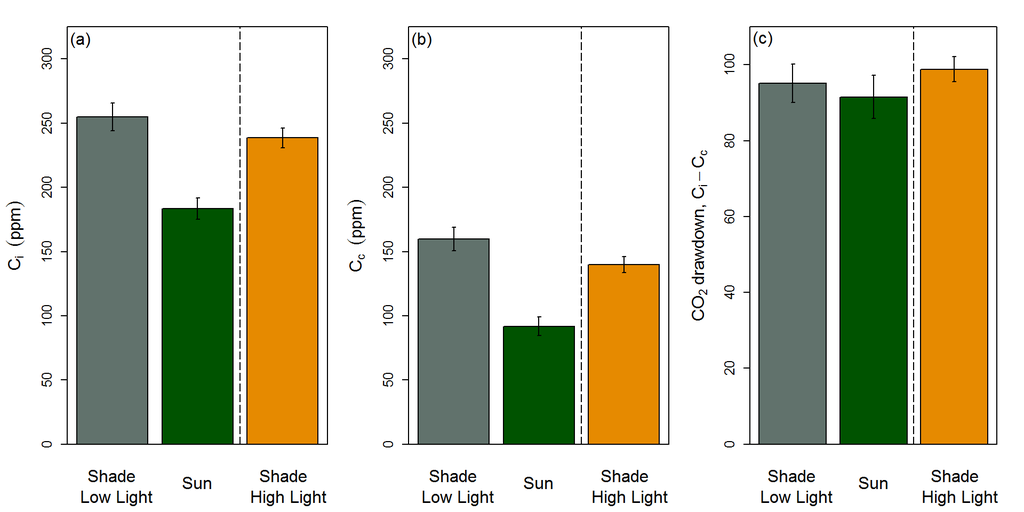

Figure 5. The mean intercellular CO<sub>2</sub> concentration (a), CO<sub>2</sub> concentration in the chloroplasts (b) and CO<sub>2</sub> drawdown from substomatal cavities to sites of carboxylation of sun leaves and shade leaves at both low and high light with standard errors.

#### Supplementary Figures

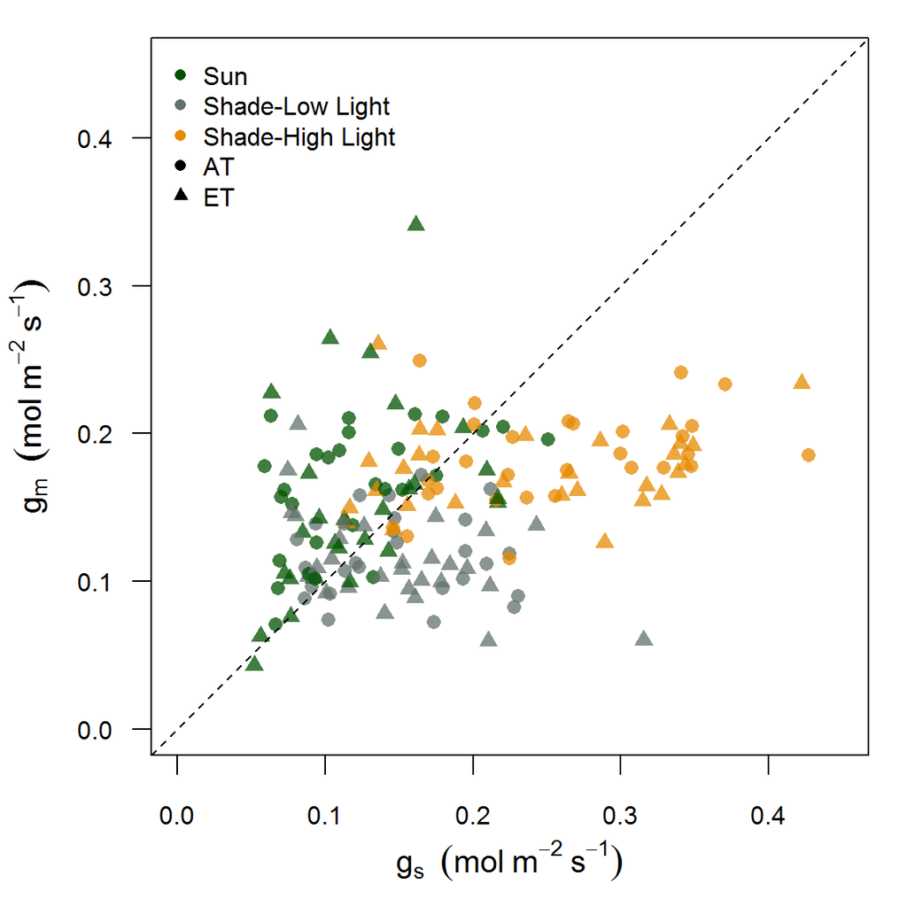

Figure S1. Mesophyll conductance as a function of stomatal conductance for sun leaves and shade leaves at both low and high light with elevated and ambient temperature treatments. The dashed line is the 1:1 relationship.

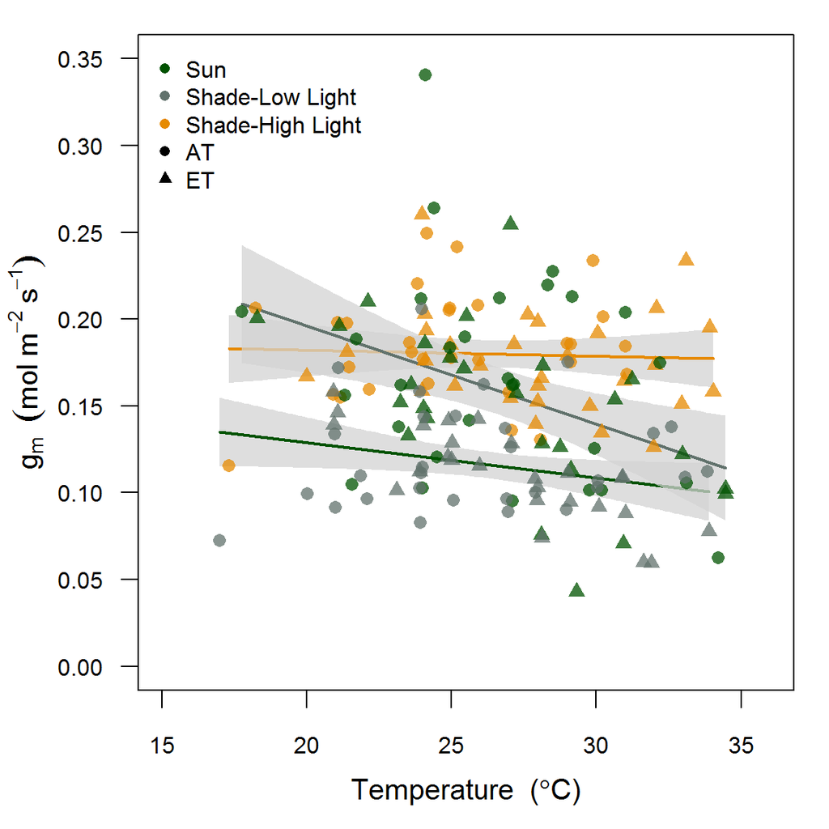

Figure S2. Response of mesophyll conductance to leaf temperature for sun and shade leaves at elevated and ambient temperature treatments. Solid lines represent linear model fits and grey areas are approximately 95% confidence intervals from the mean.

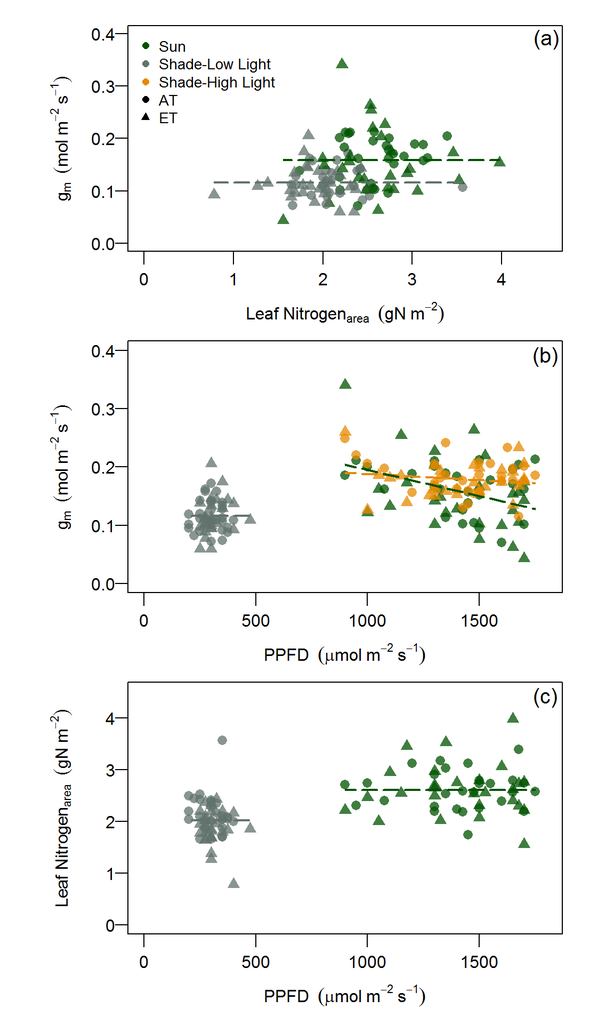

Figure S3. (a) Mesophyll conductance as a function of leaf nitrogen<sub>area</sub> for sun leaves and shade leaves at low light with elevated and ambient temperature treatments. (b) Mesophyll conductance has a function of PPFD for all leaf types. (c) Leaf nitrogen<sub>area</sub> as a function of PPFD for all leaf types. Dashed line represents linear model fits.